# Table of Contents and Notebook Setup

```python
%%javascript
$.getScript('https://kmahelona.github.io/ipython_notebook_goodies/ipython_notebook_toc.js')
```

```python
import numpy as np
import matplotlib.pyplot as plt
```

# Advanced Subplot Features

## Subplots of Unequal Scale

Sometimes we might have a figure composed of multiple plots but we don't want them to all be the same size (perhaps we have a main one and something else on the side). The following is a simple solution.

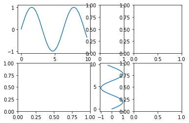

```python
x = np.arange(0, 10, 0.2)
y = np.sin(x)

fig, axes = plt.subplots(2,3, gridspec_kw = {'width_ratios':[3, 1, 2]})
axes[0, 0].plot(x,y)
axes[1, 1].plot(y,x)
fig
```

The 'gridspec_kw' argument is simple. Notie that we pass in an array of length three; this is the number of columns in the plot grid. This allows us to determine the ratio of the width of the columns. The same thing can be accomplished with the rows.

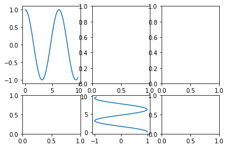

```python
x = np.arange(0, 10, 0.2)
y = np.cos(x)

fig, axes = plt.subplots(2,3, gridspec_kw = {'height_ratios':[2, 1]})
axes[0, 0].plot(x,y)
axes[1, 1].plot(y,x)
fig
```

## Subplots of Different Shape (and Management of Space)

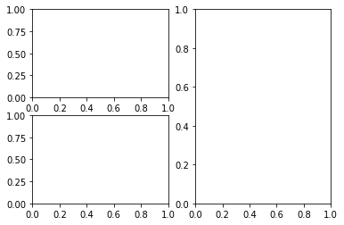

```python
fig = plt.figure()

ax1 = plt.subplot(221)
ax2 = plt.subplot(223)
ax3 = plt.subplot(122)

fig
```

The numerical arguments work as follows. The first two numbers 22 or 12 represent a 2x2 or 1x2 grid. The third number 1 or 3 or 2 represents the position in that grid that the plot should go.

Another way of accomplishing this is using the subplot2grid feature. The first tuple breaks the figure apart into a 3x3 grid. The second tuple places the top left corner of the 'ax' in that location on the grid. The colspan and rowspan then stretch out the plot so that it covers more area of the grid.

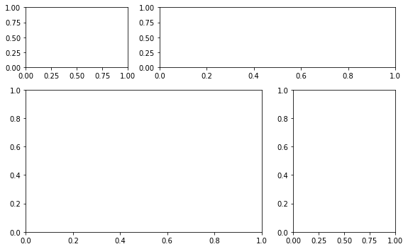

```python
fig = plt.figure(figsize=(8,5))

ax1 = plt.subplot2grid((3, 3), (0, 0))
ax2 = plt.subplot2grid((3, 3), (0, 1), colspan=2)
ax3 = plt.subplot2grid((3, 3), (1, 0), colspan=2, rowspan=2)
ax4 = plt.subplot2grid((3, 3), (1, 2), rowspan=2)

fig.tight_layout()
fig
```

Notice that the tight_layout automatically adjusts the spacing between plots so that things don't overlap.